# Airbnb_NYC_2019_Final-update2

[figure not shown]

## The first goal of this project is to create a machine learning model that can predict the price of a standard Airbnb in New York City based on the listing's features and amenities in the dataset (ie # bedrooms, TV, WiFi, etc). In addition to our price predictor, our second goal is to analyze the listings data using exploratory data analysis to pull insights that will help Airbnb to raise revenues and increase efficiency. We will do so by answering the following 3 questions: **1. Which hosts generate the most revenue?** **2. Which locations generate the most revenue?** **3. Do listings with higher ratings generate more revenue?**

In order to improve prediction accuracy and limit our data to more standard Airbnb listings, we will remove outlier data from extremely luxurious listings that are astronomically more expensive than more standard Airbnb's. The maximum price/night we will use is the tukey outlier threshold of $323 as we will see below.

*Please note that some cells in the feature-cleaning stage have been hidden in order to simplify this notebook and aid in readability. The full notebook can be found [here](https://nbviewer.jupyter.org/github/gregrosen/Data-Science-Projects/blob/master/Airbnb_NYC_Rental_Price_Prediction/Airbnb_NYC_2019_Final-update1.ipynb).*

# Importing the Data

Data retrieved from: http://insideairbnb.com/get-the-data.html.

Here we view the first 5 rows of the DataFrame to get an idea of the data's layout and features.

```python
# Import Listings Data
listings_original = pd.read_csv(os.path.join(PROJECT_ROOT_DIR, 'Data', 'listings.csv'))
listings_original.head()
```

|  | id | listing_url | scrape_id | last_scraped | name | summary | space | description | experiences_offered | neighborhood_overview | notes | transit | access | interaction | house_rules | thumbnail_url | medium_url | picture_url | xl_picture_url | host_id | host_url | host_name | host_since | host_location | host_about | host_response_time | host_response_rate | host_acceptance_rate | host_is_superhost | … |
| --- | --- | --- | --- | --- | --- | --- | --- | --- | --- | --- | --- | --- | --- | --- | --- | --- | --- | --- | --- | --- | --- | --- | --- | --- | --- | --- | --- | --- | --- | --- |
| 0 | 2539 | https://www.airbnb.com/rooms/2539 | 20190602163209 | 2019-06-03 | Clean & quiet apt home by the park | Renovated apt home in elevator building. | Spacious, renovated, and clean apt home, one b... | Renovated apt home in elevator building. Spaci... | none | Close to Prospect Park and Historic Ditmas Park | If this room is unavailable on your desired da... | Very close to F and G trains and Express bus i... | NaN | NaN | -The security and comfort of all our guests is... | NaN | NaN | https://a0.muscache.com/im/pictures/3949d073-a... | NaN | 2787 | https://www.airbnb.com/users/show/2787 | John | 2008-09-07 | New York, New York, United States | Educated professional living in Brooklyn. I l... | within an hour | 100% | NaN | f | … |
| 1 | 2595 | https://www.airbnb.com/rooms/2595 | 20190602163209 | 2019-06-03 | Skylit Midtown Castle | Find your romantic getaway to this beautiful, ... | - Spacious (500+ft²), immaculate and nicely fu... | Find your romantic getaway to this beautiful, ... | none | Centrally located in the heart of Manhattan ju... | NaN | Apartment is located on 37th Street between 5t... | Guests have full access to the kitchen, bathro... | I am a Sound Therapy Practitioner and Kundalin... | Make yourself at home, respect the space and t... | NaN | NaN | https://a0.muscache.com/im/pictures/f0813a11-4... | NaN | 2845 | https://www.airbnb.com/users/show/2845 | Jennifer | 2008-09-09 | New York, New York, United States | A New Yorker since 2000! My passion is creatin... | within a few hours | 83% | NaN | f | … |
| 2 | 3647 | https://www.airbnb.com/rooms/3647 | 20190602163209 | 2019-06-03 | THE VILLAGE OF HARLEM....NEW YORK ! | NaN | WELCOME TO OUR INTERNATIONAL URBAN COMMUNITY T... | WELCOME TO OUR INTERNATIONAL URBAN COMMUNITY T... | none | NaN | NaN | NaN | NaN | NaN | Upon arrival please have a legibile copy of yo... | NaN | NaN | https://a0.muscache.com/im/pictures/838341/9b3... | NaN | 4632 | https://www.airbnb.com/users/show/4632 | Elisabeth | 2008-11-25 | New York, New York, United States | Make Up Artist National/ (Website hidden by Ai... | within a day | 100% | NaN | f | … |
| 3 | 3831 | https://www.airbnb.com/rooms/3831 | 20190602163209 | 2019-06-03 | Cozy Entire Floor of Brownstone | Urban retreat: enjoy 500 s.f. floor in 1899 br... | Greetings! We own a double-duplex brownst... | Urban retreat: enjoy 500 s.f. floor in 1899 br... | none | Just the right mix of urban center and local n... | NaN | B52 bus for a 10-minute ride to downtown Brook... | You will have exclusive use of and access to: ... | We'll be around, but since you have the top fl... | Smoking - outside please; pets allowed but ple... | NaN | NaN | https://a0.muscache.com/im/pictures/e49999c2-9... | NaN | 4869 | https://www.airbnb.com/users/show/4869 | LisaRoxanne | 2008-12-07 | New York, New York, United States | Laid-back bi-coastal actor/professor/attorney. | within an hour | 100% | NaN | f | … |
| 4 | 4989 | https://www.airbnb.com/rooms/4989 | 20190602163209 | 2019-06-03 | Great 1 bdrm. apartment in the PERFECT location! | Best location in NYC (the greatest city in the... | Quiet, artsy, 1 bdrm. apt. in Hell's Kitchen (... | Best location in NYC (the greatest city in the... | none | Hell's Kitchen is a safe, popular, and desirab... | Enjoy! | NYC subways and the Hudson River are each just... | The apt. is all yours. | Reach me via phone, text, email, etc. And I'll... | Keep things clean and orderly and quiet please... | NaN | NaN | https://a0.muscache.com/im/pictures/ebafaaa6-d... | NaN | 7118 | https://www.airbnb.com/users/show/7118 | New-Yorker | 2009-01-26 | New York, New York, United States | Professional Designer/Artist working in Theatr... | within a day | 50% | NaN | f | … |

# Cleaning the Data

We will begin by splitting the data into train and test sets. We will only be observing the training set to avoid any bias from assumptions made based on the testing data. We will not touch the testing data until our final model is ready for production to test its accuracy.

```python
# Copy original DataFrame
listings = listings_original.loc[:,listings_original.columns]
```

```python
# Check for duplicates
listings.duplicated().sum()
```

```
0
```

```python
# Create train/test sets
from sklearn.model_selection import train_test_split
listings_train, listings_test = train_test_split(listings.loc[:,listings.columns],
                                                 test_size=0.2, random_state=42)
```

We will now copy our training data as an exploratory DataFrame that we can experimentally modify without affecting our original training set.

```python
# Copy listings_train for data exploration
listings_explore = listings_train.loc[:,listings_train.columns]
```

# Preliminary Feature Elimination

We will now drop features that most obviously exceed the missing value limits or are not useful for our analysis and model.

```python
# Drop obviously unnecessary features
dropped_cols = []
dropped_cols.extend([
 # Unnecessary features:
 'id','host_id','listing_url','scrape_id','last_scraped','name','summary','space','description','neighborhood_overview','notes','transit',
 'access','interaction','house_rules','thumbnail_url','medium_url','picture_url','xl_picture_url','host_url','host_name','host_about',
 # Features with too many missing values:
 'host_response_time','host_response_rate','host_acceptance_rate','host_thumbnail_url','host_picture_url','square_feet',
 'weekly_price','monthly_price','security_deposit','license','jurisdiction_names'
 ])
listings_explore.drop(columns=dropped_cols, inplace=True)
```

# Univariate Feature Cleaning

Now that we have removed the removed the features that are obviously not valuable, we will further explore the values within our remaining features to determine which features to use in our analysis and model. We will do so by checking the top 5 and bottom 5 values and frequencies (`value_count`] of each value in a given feature to better understand what the feature consists of.

## **Feature: host_location**

We drop host_location because it seems to be an arbitrary fill-in from the hosts, and their location is not the location of the airbnb's location.

```python
# check values for host_location
print(listings_explore.host_location.value_counts()[:5])
print(listings_explore.host_location.value_counts()[-5:])
```

```
New York, New York, United States         26044
US                                         3954
Brooklyn, New York, United States          2919
Queens, New York, United States             978
Los Angeles, California, United States      234
Name: host_location, dtype: int64
West Berlin, New Jersey, United States      1
Montreuil, Île-de-France, France            1
Flemington, New Jersey, United States       1
Baku, Azerbaijan                            1
Mammoth Lakes, California, United States    1
Name: host_location, dtype: int64
```

## **Feature: host_neighbourhood**

Drop because unnecessary host manual fill-in information.

```python
# check values for host_neighbourhood
print(listings_explore.host_neighbourhood.value_counts()[:5])
print(listings_explore.host_neighbourhood.value_counts()[-5:])
```

```
Williamsburg          2801
Bedford-Stuyvesant    2383
Bushwick              1676
Upper East Side       1396
Hell's Kitchen        1388
Name: host_neighbourhood, dtype: int64
Dupont Circle         1
Shuangjing            1
Warehouse District    1
Alésia                1
Venice                1
Name: host_neighbourhood, dtype: int64
```

## **Feature: host_verifications**

Drop because this is unnecessary corporate information that is invisible to the renter.

```python
# check values for host_verifications
print(listings_explore.host_verifications.value_counts()[:5])
```

```
['email', 'phone', 'reviews', 'kba']                                                                             4004
['email', 'phone', 'reviews', 'jumio', 'government_id']                                                          3729
['email', 'phone']                                                                                               2774
['email', 'phone', 'reviews']                                                                                    2396
['email', 'phone', 'reviews', 'jumio', 'offline_government_id', 'selfie', 'government_id', 'identity_manual']    1686
Name: host_verifications, dtype: int64
```

We have finished our preliminary feature cleaning. We are currently working with 57 features, excluding amenities which will be formatted later.

# Feature Cleaning and Univariate Analysis

Now that we have eliminated preliminary features, we will take a deeper look at each feature and modify as needed.

```python
# Lists of each type of attribute (to be filled as each feature is analyzed)
num_attribs = []
disc_attribs = []
cat_attribs = []
drop_attribs = []
drop_later = []
```

First, we will create a few functions for feature analysis. In hidden cells, we create functions called `preliminaries` to display feature dtype, missing values, and value counts, `sum_stats` to generate summary statistics of a given feature, and `percentage_of` to calculate a given value's percentage of the total values.

We will now view a visual representation of the distribution of missing values in our DataFrame. This way we can confirm that none of our features have more than 20-30% missing values.

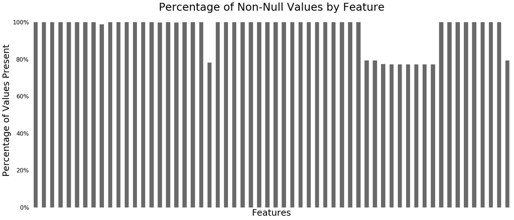

```python
# Barplot of existing values vs. missing values
plt.figure()
plt.xlabel('Features', fontsize=25)
plt.ylabel('Percentage of Values Present', fontsize=25)
fig = missingno.bar(listings_explore)
fig.set_yticklabels(['0%','20%','40%','60%','80%','100%'])
plt.title('Percentage of Non-Null Values by Feature', fontsize=30)
plt.show()
```

# Numerical Features

First, we will analyze the numerical features. In hidden cells we create functions for analysis called `tukey_outliers` to identify Tukey outliers, `cdf` to plot a cdf, and `percentile` to calculate the percentile of a given score.

```python
preliminaries(listings_explore, 'price')
```

```
Dtype:  object
Missing Values:  0
```

```python
# Value counts
print(listings_explore.price.value_counts()[:5])
```

```
$150.00    1670
$100.00    1569
$50.00     1242
$60.00     1165
$200.00    1103
Name: price, dtype: int64
```

As we can see below, many of our numerical features are of dtype string, and have string characters such as "$" that must be removed before converting them to float or int.

```python
# Remove string characters, convert to float
listings_explore['price'] = listings_explore['price'].astype('str').copy()
listings_explore['price'] = listings_explore['price'].str.replace('.00', '', regex=False).copy()
listings_explore['price'] = listings_explore['price'].str.replace('$', '', regex=False).copy()
listings_explore['price'] = listings_explore['price'].str.replace(',', '', regex=False).copy()
listings_explore['price'] = listings_explore['price'].astype('float64').copy()
```

```python
# Check Tukey outlier range
tukey_outliers(listings_explore.price)
```

```
(-90.0, 334.0)
```

```python
# Check percentile of $323 ceiling price
scipy.stats.percentileofscore(listings_explore.price, 323)
```

```
93.34144467213115
```

Although our current Tukey outlier range tells us the outlier is at 334, after we clean many features below, the Price outlier value becomes 323. It would be improper to consider the outlier *before* feature cleaning, as we would be cleaning the features below based on a premature assumption.

```python
# only include price in range [10, 323]
listings_explore = listings_explore[(listings_explore.price < 323) & (listings_explore.price >= 10)]
```

```python
sum_stats(listings_explore.price)
```

```
nobs: 36432
median: 100.0
mode: [150.]
mean: 119.07444005270092
std: 66.94934559205603
minmax: (10.0, 322.0)
25% 65.0
50% 100.0
75% 157.0
skewness: 0.8964214310633671
```

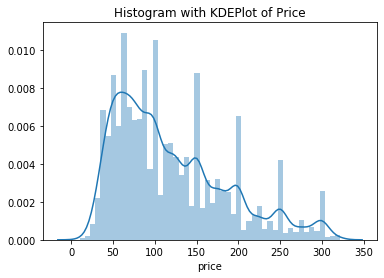

```python
sns.distplot(listings_explore.price, bins=50)
plt.title('Histogram with KDEPlot of Price')
plt.show()
```

Here we see Price is a skewed right distribution with clear modes at even price values like 50, 75, 100, 125, 150, 200, 250, 300. This is due to hosts pricing their listings at even values.

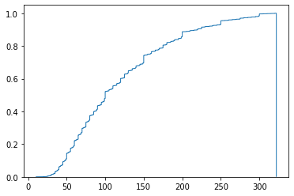

```python
# Price CDF
cdf(listings_explore, 'price')
```

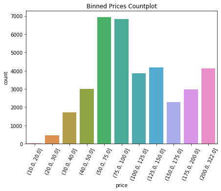

```python
# View binned prices
price_bin = pd.cut(listings_explore.price, [10,20,30,40,50,75,100,125,150,175,200,listings_explore.price.max()])
plt.figure(figsize=(7,5))
fig = sns.countplot(price_bin)
fig.set_xticklabels(fig.get_xticklabels(), rotation=65)
plt.title('Binned Prices Countplot')
plt.show()
```

## **Feature: number_of_reviews_ltm** (last twelve months) (discrete)

```python
preliminaries(listings_explore, 'number_of_reviews_ltm')
```

```
Dtype:  int64
Missing Values:  0
```

In order to isolate listings that are actually rented on a regular basis, we will assume that listings that are regularly rented will have at least 1 review in the last 12 months. Before dropping all listings with 0 reviews in ltm, we will check to confirm this is not solely due to new hosts who have not had enough time to accrue reviews:

```python
# number of listings with host_since==0 and number_of_reviews_ltm==0
len(listings_explore[(listings_explore.host_since == 0) & (listings_explore.number_of_reviews_ltm == 0)])
```

```
0
```

```python
# only include number_of_reviews_ltm > 0
listings_explore = listings_explore[listings_explore.number_of_reviews_ltm > 0]
```

```python
sum_stats(listings_explore.number_of_reviews_ltm)
```

```
nobs: 21998
median: 8.0
mode: [1]
mean: 15.640785525956906
std: 18.4863398234607
minmax: (1, 282)
25% 3.0
50% 8.0
75% 23.0
skewness: 2.4239319779583917
```

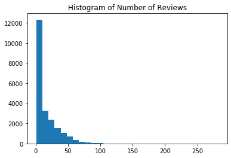

```python
plt.hist(listings_explore.number_of_reviews_ltm, bins=30)
plt.title('Histogram of Number of Reviews')
plt.show()
```

```python
sum_stats(listings_explore.host_since.dropna())
```

```
nobs: 21994
median: 4.0
mode: [4.]
mean: 4.191324906792762
std: 2.3706946253180505
minmax: (0.0, 11.0)
25% 2.0
50% 4.0
75% 6.0
skewness: 0.17188379478247912
```

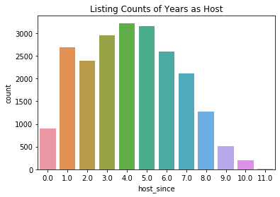

```python
# Countplot
sns.countplot(listings_explore.host_since)
plt.title('Listing Counts of Years as Host')
plt.show()
```

Most hosts are spread rather evenly between 1 year and 7 years. 0 and 8-10 years are still significant amount. Skews slightly right.

```python
sum_stats(listings_explore.accommodates)
```

```
nobs: 21998
median: 2.0
mode: [2]
mean: 2.8161196472406584
std: 1.682256249145391
minmax: (1, 16)
25% 2.0
50% 2.0
75% 4.0
skewness: 2.1068170931469448
```

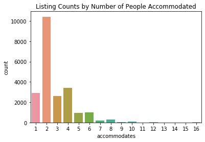

```python
sns.countplot(listings_explore.accommodates)
plt.title('Listing Counts by Number of People Accommodated')
plt.show()
```

## **Feature: bathrooms** (discrete)

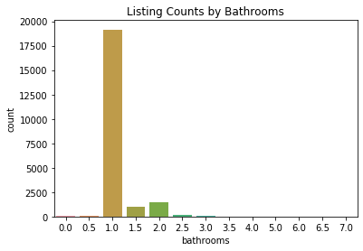

```python
sns.countplot(listings_explore.bathrooms)
plt.title('Listing Counts by Bathrooms')
plt.show()
```

87% of all listings have 1 bathroom, while nearly all have 3 or less. Skews right.

## **Feature: bedrooms** (discrete)

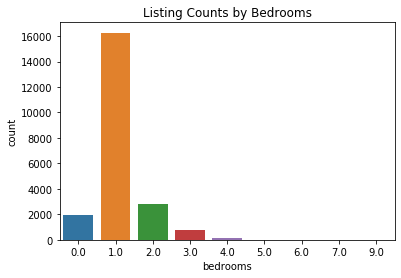

```python
sns.countplot(listings_explore.bedrooms)
plt.title('Listing Counts by Bedrooms')
plt.show()
```

74% of listings have 1 bedroom, and nearly all have 4 or less. Skews right.

## **Feature: cleaning_fee**

```python
# Drop cleaning fees exceeding maximum price of $323
cleaning_fee_drop = np.array(listings_explore[listings_explore.cleaning_fee>323].index)
listings_explore.drop(index=cleaning_fee_drop, inplace=True)
```

In order to eliminate unrealistic cleaning fees, we drop those that exceed the maximum listing price of $323.

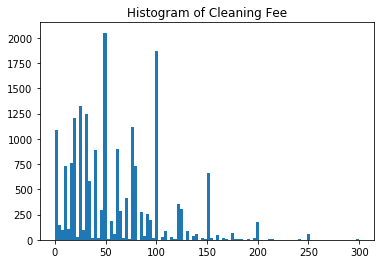

```python
plt.hist(listings_explore.cleaning_fee.dropna(), bins=100)
plt.title('Histogram of Cleaning Fee')
plt.show()
```

To visualize the distribution's shape:

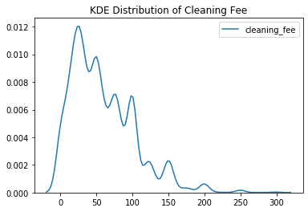

```python
sns.kdeplot(listings_explore.cleaning_fee.dropna())
plt.title('KDE Distribution of Cleaning Fee')
plt.show()
```

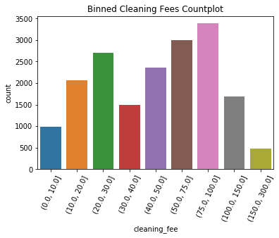

```python
# View binned cleaning fees
cleaning_fee_bin = pd.cut(listings_explore['cleaning_fee'], [0,10,20,30,40,50,75,100,150,listings_explore.cleaning_fee.max()])
plt.figure(figsize=(6,4))
fig = sns.countplot(cleaning_fee_bin)
fig.set_xticklabels(fig.get_xticklabels(), rotation=65)
plt.title('Binned Cleaning Fees Countplot')
plt.show()
```

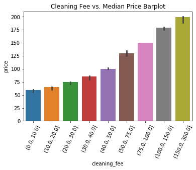

```python
# Cleaning fee vs. median price
fig = sns.barplot(cleaning_fee_bin, listings_explore.price, estimator=median)
fig.set_xticklabels(fig.get_xticklabels(), rotation=65)
plt.title('Cleaning Fee vs. Median Price Barplot')
plt.show()
```

Median cleaning fee is 50, 95% are 150 or less, but they can range up to 300. Mode is also 50, but the mode of our binned cleaning fees are in the 75-100 range. From our barplot above, higher cleaning fees tend to have higher median prices, which makes sense seeing as it should be more expensive to clean more expensive listings.

## **Feature: minimum_nights** (discrete)

The minimum_nights feature contains values above 180 nights (6 months), but Airbnb's policy states an Airbnb's maximum stay can be 6 months. This is likely a manual fill-in field for the host, as Airbnb would not provide attributes that violate its own policy. Airbnb may want to review this field to restrict minimum nights to 6 months or less. For our analysis of more standard Airbnb's, we will drop all rows whose minimum_nights exceed 7 nights in order to isolate Airbnb's available for short-term stays, as long-term Airbnb's are much more rare than short-term and nightly prices are often discounted.

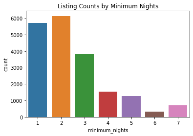

```python
sns.countplot(listings_explore.minimum_nights)
plt.title('Listing Counts by Minimum Nights')
plt.show()
```

Most listings have 1-3 night minimum, but it ranges up to 7, with outliers at 6+. Skews right.

**Features: minimum_minimum_nights, maximum_minimum_nights, minimum_maximum_nights, maximum_maximum_nights, minimum_nights_avg_ntm, maximum_nights_avg_ntm**

We will drop these specific features in lieu of the features: minimum_nights and maximum_nights. NTM means 'next twelve months.'

# Categorical Features

## **Feature: host_is_superhost**

```python
preliminaries(listings_explore, 'host_is_superhost', values=True)
```

```
Dtype:  object
Missing Values:  4
f    13978
t     5518
Name: host_is_superhost, dtype: int64
```

```python
# Convert t/f to 1/0
listings_explore['host_is_superhost'] = convert_tf(listings_explore, 'host_is_superhost')
```

```python
preliminaries(listings_explore, 'host_is_superhost', values=True)
```

```
Dtype:  float64
Missing Values:  4
0.0    13978
1.0     5518
Name: host_is_superhost, dtype: int64
```

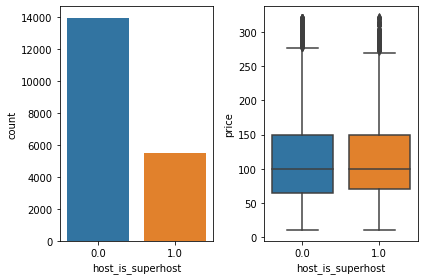

```python
fig, ax = plt.subplots(1, 2)
sns.countplot(listings_explore.host_is_superhost, ax=ax[0])
sns.catplot('host_is_superhost', 'price', data=listings_explore, kind='box', ax=ax[1])
fig.tight_layout()
plt.close()
plt.show()
```

28% of hosts are superhosts. Interestingly, price does not look to be affected by whether a host is a superhost or not. If this is true, then the superhost badge is more a marketing tool for Airbnb to synthetically reward loyal hosts than it is a tool to help hosts generate more revenue.

## **Feature: property_type**

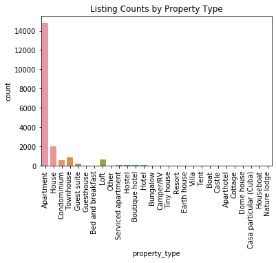

```python
fig = sns.countplot(listings_explore.property_type)
fig.set_xticklabels(labels=pd.unique(listings_explore.property_type), rotation=90)
plt.title('Listing Counts by Property Type')
plt.show()
```

Because we are isolating more standard Airbnbs, we will only keep the following property types from the data:

```python
# Filter specific property types
listings_explore = listings_explore[
                       (listings_explore.property_type == 'Apartment') |
                       (listings_explore.property_type == 'House') |
                       (listings_explore.property_type == 'Condominium') |
                       (listings_explore.property_type == 'Townhouse') |
                       (listings_explore.property_type == 'Guest suite') |
                       (listings_explore.property_type == 'Guesthouse') |
                       (listings_explore.property_type == 'Loft') |
                       (listings_explore.property_type == 'Serviced apartment') |
                       (listings_explore.property_type == 'Tiny house') |
                       (listings_explore.property_type == 'Earth house') |
                       (listings_explore.property_type == 'Villa') |
                       (listings_explore.property_type == 'Castle') |
                       (listings_explore.property_type == 'Cottage') |
                       (listings_explore.property_type == 'Dome house')
                    ]
```

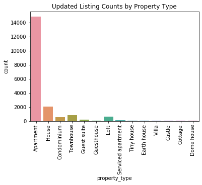

```python
fig = sns.countplot(listings_explore.property_type)
fig.set_xticklabels(labels=pd.unique(listings_explore.property_type), rotation=90)
plt.title('Updated Listing Counts by Property Type')
plt.show()
```

77% of listings are apartments, 11% are houses, with the remaining 10% in condominiums, townhomes, lofts, and only a few of the others.

## **Feature: amenities**

The amenities feature originally consists of string lists of each amenity of the listing. We split this into binary columns for each amenity in order to accurately measure each amenity each listing has.

```python
# Example of amenity string list
listings_explore.amenities[0]
```

```
'{TV,"Cable TV",Internet,Wifi,"Wheelchair accessible",Kitchen,"Free parking on premises",Elevator,"Free street parking","Buzzer/wireless intercom",Heating,"Suitable for events",Washer,Dryer,"Smoke detector","Carbon monoxide detector","First aid kit","Safety card","Fire extinguisher",Essentials,Shamp…
```

```python
# Remove empty values ({})
listings_explore = listings_explore[listings_explore.amenities != '{}']
```

```python
# Remove brackets and quotes, split by ','
listings_explore['amenities'] = listings_explore.amenities.astype('str').str.replace('{', '', regex=False)
listings_explore['amenities'] = listings_explore.amenities.str.replace('}', '', regex=False)
listings_explore['amenities'] = listings_explore.amenities.str.replace('"', '', regex=False)
listings_explore['amenities'] = listings_explore.amenities.str.split(',')
```

```python
# Create columns for each amenity using MultiLabelBinarizer
from sklearn.preprocessing import MultiLabelBinarizer

mlb = MultiLabelBinarizer()
amenities_df = pd.DataFrame(mlb.fit_transform(listings_explore.amenities))
classes = mlb.classes_ # amenity names
amenities_df.columns = classes # add amenity names as columns
```

```python
# Test view a row of amenities
amenities_df.head(1)
```

|  | toilet | 24-hour check-in | Accessible-height bed | Accessible-height toilet | Air conditioning | Air purifier | BBQ grill | Baby bath | Baby monitor | Babysitter recommendations | Bathtub | Bathtub with bath chair | Beach essentials | Beachfront | Bed linens | Breakfast | Building staff | Buzzer/wireless intercom | Cable TV | Carbon monoxide detector | Cat(s) | Ceiling hoist | Changing table | Children’s books and toys | Children’s dinnerware | Cleaning before checkout | Coffee maker | Cooking basics | Crib | … |
| --- | --- | --- | --- | --- | --- | --- | --- | --- | --- | --- | --- | --- | --- | --- | --- | --- | --- | --- | --- | --- | --- | --- | --- | --- | --- | --- | --- | --- | --- | --- |
| 0 | 1 | 0 | 1 | 0 | 1 | 0 | 0 | 0 | 0 | 0 | 0 | 0 | 1 | 0 | 1 | 0 | 0 | 0 | 0 | 1 | 0 | 0 | 0 | 1 | 0 | 0 | 0 | 1 | 0 | … |

```python
# Save indices
indices = np.array(listings_explore.index)
# Merge new amenities columns with original dataframe
listings_explore = pd.concat([listings_explore.reset_index(drop=True), amenities_df.reset_index(drop=True)], axis=1)
# Reapply original indices
listings_explore = listings_explore.set_index(indices)
# Drop 'amenities' column
listings_explore.drop(columns='amenities', inplace=True)
# Test view DataFrame with amenities added
listings_explore.head(1)
```

|  | host_since | host_is_superhost | host_listings_count | host_identity_verified | neighbourhood_cleansed | neighbourhood_group_cleansed | latitude | longitude | property_type | room_type | accommodates | bathrooms | bedrooms | beds | bed_type | price | cleaning_fee | guests_included | extra_people | minimum_nights | maximum_nights | calendar_updated | has_availability | availability_30 | availability_60 | availability_90 | availability_365 | number_of_reviews | number_of_reviews_ltm | … |
| --- | --- | --- | --- | --- | --- | --- | --- | --- | --- | --- | --- | --- | --- | --- | --- | --- | --- | --- | --- | --- | --- | --- | --- | --- | --- | --- | --- | --- | --- | --- |
| 37753 | 2.0 | 0.0 | 1.0 | 0.0 | Bushwick | Brooklyn | 40.70229 | -73.92223 | Apartment | Private room | 2 | 1.0 | 1.0 | 1.0 | Real Bed | 85.0 | 25.0 | 1 | 20.0 | 1 | 60 | 2 months ago | t | 6 | 20 | 50 | 325 | 38 | 38 | … |

# Feature Correlation

Now that we have finished our first round of feature cleaning and analysis, we will move on to analyzing feature correlations.

Here, we will analyze Pearson and Spearman (linear and non-linear) feature correlations in order to remove features with high collinearity, and identify features highly correlated with our label feature 'price'.

### Pearson Linear Correlations

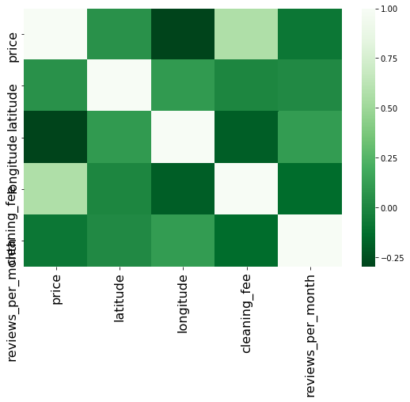

```python
# Pearson Correlation Matrix
pearson_cols = num_attribs.copy()
fig, ax = plt.subplots(figsize=(9,6))
sns.heatmap(listings_explore[pearson_cols].corr(method='pearson'), cmap='Greens_r', ax=ax)
ax.tick_params(labelsize=16)
```

Our numerical variables are not highly correlated to each other. Cleaning fee has the highest correlation to price.

We will now create a Spearman correlation matrix in order to measure non-linear correlations between our ordinal and categorical features.

### Spearman Non-Linear Correlations

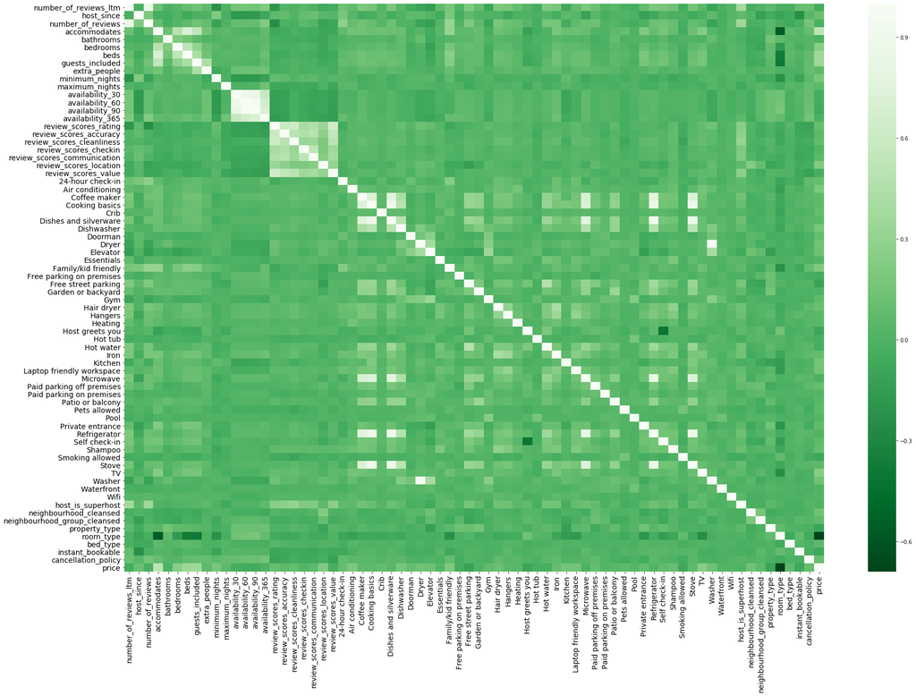

```python
# Spearman Correlation Matrix
# Create spearman dataframe
from sklearn.preprocessing import OrdinalEncoder
from sklearn.impute import SimpleImputer
spearman_df = listings_explore.loc[:,listings_explore.columns]
spearman_df.dropna(axis=0,inplace=True)
spearman_df[cat_attribs] = OrdinalEncoder().fit_transform(spearman_df[cat_attribs])
# Create spearman columns
spearman_cols = []
spearman_cols.extend(disc_attribs)
spearman_cols.extend(amen_attribs)
spearman_cols.extend(cat_attribs)
spearman_cols.append('price')
# Create heatmap
fig, ax = plt.subplots(figsize=(30,20))
sns.heatmap(spearman_df[spearman_cols].corr(method='spearman'), cmap='Greens_r', ax=ax)
ax.tick_params(labelsize=14)
```

Based on feature correlations, we will remove features with high collinearity.

```python
# Drop highly correlated features
corr_drop = ['number_of_reviews_ltm', # keep number_of_reviews (higher corr with price)
             'availability_60', 'availability_90', # keep availability_30,
             'review_scores_accuracy', 'review_scores_cleanliness', 'review_scores_checkin', 'review_scores_value', # keep rating and location
             'Dishes and silverware', 'Coffee maker', 'Refrigerator', 'Microwave', 'Stove', # keep cooking_basics
             'Dryer', # keep washer
            ]
```

```python
# List of features highly correlated with price
highly_correlated = ['host_since', # discrete
                     'host_listings_count', # discrete
                     'longitude', # numerical
                     'accommodates', # discrete
                     'bedrooms', # discrete
                     'beds', # discrete
                     'cleaning_fee', # numerical
                     'guests_included', # discrete
                     'minimum_nights', # discrete
                     'review_scores_location', # discrete
                     'instant_bookable', # categorical
                     'reviews_per_month', # numerical
                     'Free parking on premises', # categorical
                     'Free street parking', # # categorical
                     'Host greets you', # categorical
                     'Hot water', # categorical
                     'Smoking allowed', # categorical
                     'TV', # categorical
                    ]
```

# Missing Value Imputation (for exploration of data)

This missing value imputation using Pandas is for the multi-variate analysis below, but the true missing value imputations are performed later in our Scikit-Learn Pipeline and ColumnTransformer (with the same mean/mode strategy).

```python
# Impute missing values
listings_explore.fillna(listings_explore[num_attribs].mean(), inplace=True) # mean for numerical
listings_explore.fillna(listings_explore[disc_attribs].mode().iloc[0], inplace=True) # mode
listings_explore.fillna(listings_explore[cat_attribs].mode().iloc[0], inplace=True) # mode
listings_explore.fillna(listings_explore[amen_attribs].mode().iloc[0], inplace=True) # mode
```

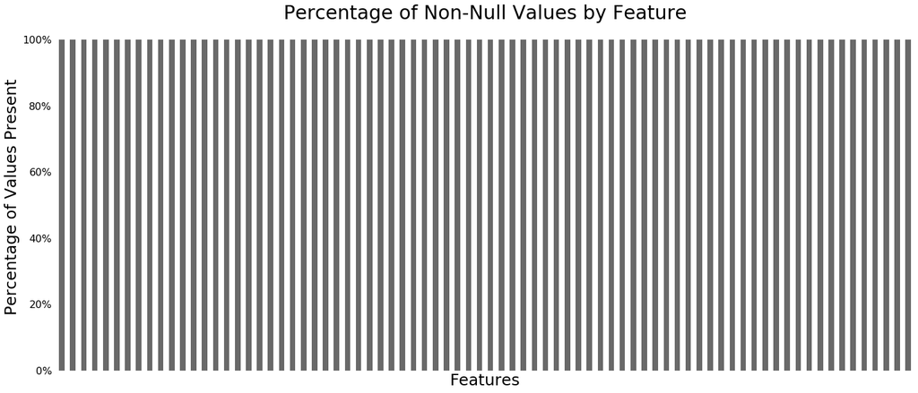

```python
# Confirm missing values imputed
plt.figure()
plt.xlabel('Features', fontsize=25)
plt.ylabel('Percentage of Values Present', fontsize=25)
fig = missingno.bar(listings_explore)
fig.set_yticklabels(['0%','20%','40%','60%','80%','100%'])
plt.title('Percentage of Non-Null Values by Feature', fontsize=30)
plt.show()
```

# Statistical Analysis of Numerical Features

```python
# Function to plot pearsonr and p-value for regplots
from scipy.stats import pearsonr
def corrfunc(x, y, **kws):
    (r, p) = pearsonr(x, y)
    ax = plt.gca()
    ax.annotate("r = {:.2f} ".format(r),
                xy=(.1, .9), xycoords=ax.transAxes)
    ax.annotate("p = {:.3f}".format(p),
                xy=(.4, .9), xycoords=ax.transAxes)
```

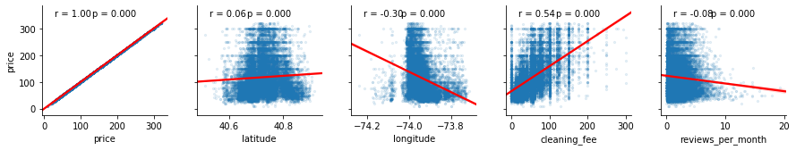

```python
# Regplot numerical features
fig = sns.pairplot(x_vars = num_attribs, y_vars='price', data=listings_explore, kind='reg',
             plot_kws={'line_kws':{'color':'red'}, 'scatter_kws': {'alpha': 0.1, 's': 5}})
fig.map(corrfunc)
plt.show()
```

Cleaning fee positively correlates highest with price--cleaning fees increase with price. This makes sense, as higher prices would proportionately command higher cleaning fees.

# Multi-Variate Analysis

For our multi-variate analysis, we will think about the important questions we are looking to answer with this data. Our focus is on business intelligence that will help Airbnb gain insights into its market and drive efficiency and revenue. Specifically, our data revolves around our hosts and their property information, so we will center our questions and strategy around hosts and location with the following questions:

**1. Which hosts generate the most revenue?**

**2. Which locations generate the most revenue?**

**3. Do listings with higher ratings generate more revenue?**

# Question 1: Which hosts generate the most revenue?

### Which hosts have the most listings?

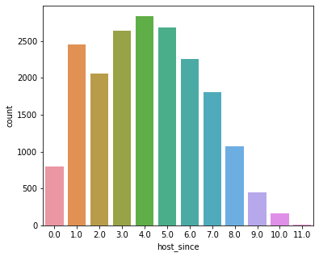

```python
plt.figure(figsize=(6,5))
sns.countplot(listings_explore.host_since)
plt.show()
```

```python
# Percentage of total listings by hosts hosting for 1-7 years
percentage_of(listings_explore.host_since, [1,2,3,4,5,6,7]).sum()
```

```
0.88
```

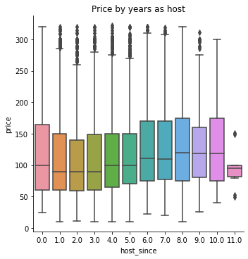

```python
sns.catplot(x='host_since', y='price', data=listings_explore, kind='box', showfliers=True)
plt.title('Price by years as host')
plt.show()
```

Median price is rather uniform regardless of years hosting (rises slightly for hosts 6yrs+), which means our highest revenue generators by group are hosts with the highest frequencies. Therefore, hosts who have been hosting from 1-7 years generate the most revenue. However, it is important to note that our most loyal hosts who have been hosting for many years (8+) may not be as populous for acute revenue generation by frequency, but their loyalty has generated consistent revenue for many years longer than even the highest revenue-generating hosts.

Yet, we must still check the frequencies of availability.

### Which hosts have the most frequent bookings?

First, we will plot the distribution of all listings' availabilities in the past year.

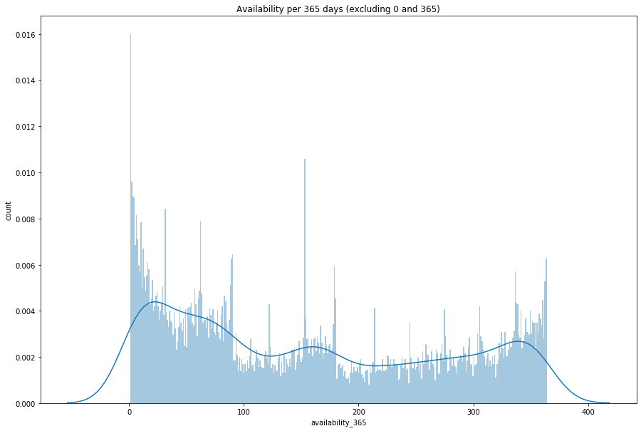

```python
plt.figure(figsize=(15,10))
sns.distplot(listings_explore[(listings_explore.availability_365 > 0) & (listings_explore.availability_365 < 365)].availability_365, bins=364)
plt.xlabel('availability_365')
plt.ylabel('count')
plt.title('Availability per 365 days (excluding 0 and 365)')
plt.show()
```

The distribution of availabilities in the past year skews slightly right, but is still rather uniform, with the lowest values ranging from 100-325. We will now segment by host_since to confirm whether certain segments of hosts rent their listings more frequently.

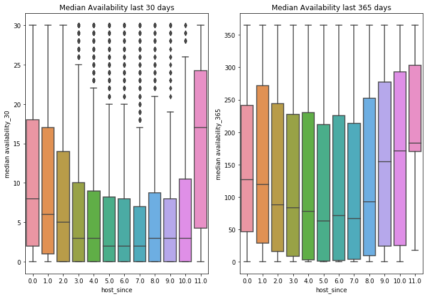

```python
fig, ax = plt.subplots(1,2,figsize=(10,7))
sns.boxplot(x='host_since', y='availability_30', data=listings_explore, ax=ax[0])
ax[0].set_ylabel('median availability_30')
ax[0].set_title('Median Availability last 30 days')
sns.boxplot(x='host_since', y='availability_365', data=listings_explore, ax=ax[1])
ax[1].set_ylabel('median availability_365')
ax[1].set_title('Median Availability last 365 days')
fig.tight_layout()
plt.show()
```

#### Superhost Status

We will now segment the hosts by superhost status to determine whether superhosts generate more revenue.

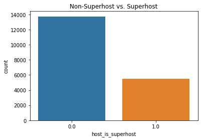

```python
sns.countplot(listings_explore.host_is_superhost)
plt.title('Non-Superhost vs. Superhost')
plt.show()
```

```python
percentage_of(listings_explore.host_is_superhost, 1)
```

```
0.29
```

29% of hosts are superhosts.

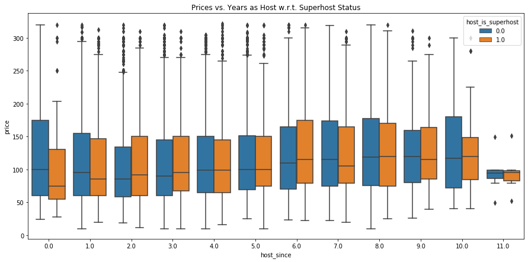

```python
plt.figure(figsize=(15,7))
sns.boxplot(x='host_since', y='price', data=listings_explore,
            hue='host_is_superhost', showfliers=True)
plt.title('Prices vs. Years as Host w.r.t. Superhost Status')
plt.show()
```

Superhosts do not seem to command higher prices than non-superhosts.

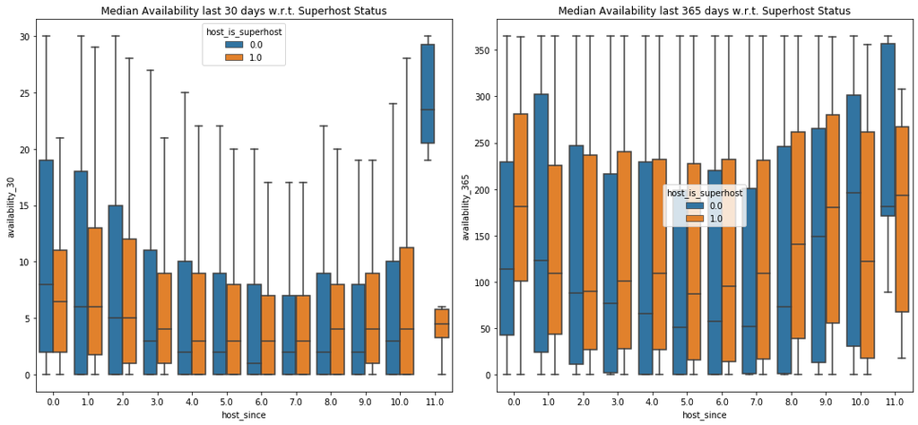

```python
fig, ax = plt.subplots(1,2,figsize=(15,7))
sns.boxplot(x='host_since', y='availability_30', data=listings_explore,
            hue='host_is_superhost', showfliers=False, ax=ax[0])
ax[0].set_ylabel('availability_30')
ax[0].set_title('Median Availability last 30 days w.r.t. Superhost Status')
sns.boxplot(x='host_since', y='availability_365', data=listings_explore,
            hue='host_is_superhost', showfliers=False, ax=ax[1])
ax[1].set_ylabel('availability_365')
ax[1].set_title('Median Availability last 365 days w.r.t. Superhost Status')
fig.tight_layout()
plt.show()
```

Moving forward, we would need more datapoints to determine the ratios of days the listings are actually available versus the days rented because hosts may not make their listing available every night of the month/year. But with the information we currently have, it seems there is no significant difference between superhosts and non-superhosts when it comes to median prices and frequency of rents.